# Causal machine learning

Riccardo Di Francesco

University of Southern Denmark

## Introduction

**Correlation $\neq$ causation**

We often see variables move together. But this correlation does not necessarily imply that one variable causes the other.

A third factor$—$called confounder$—$can increase/decrease both, creating a non-causal association.

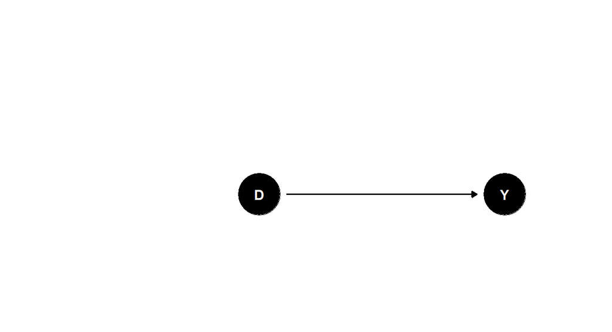

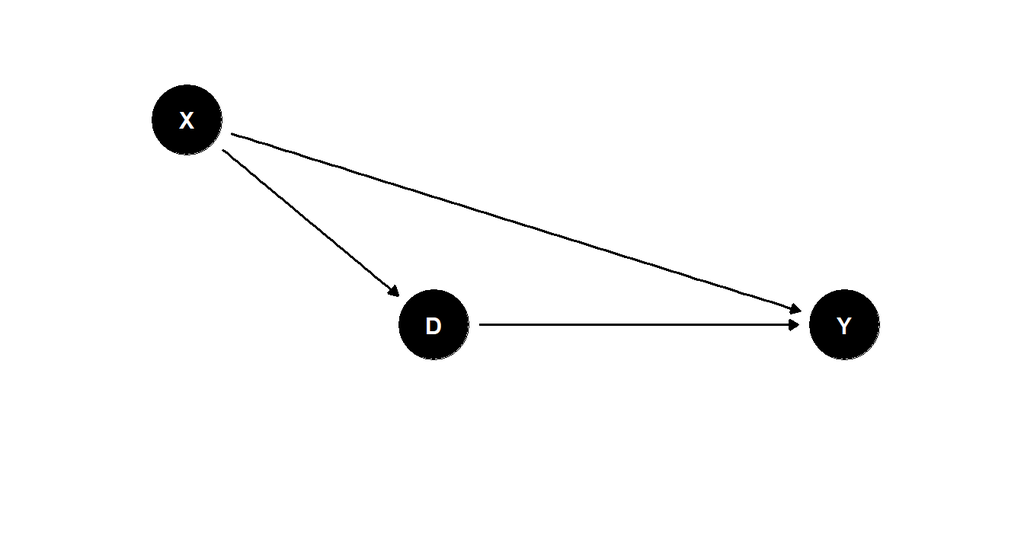

[figure not shown]

[figure not shown]

## Identification vs. estimation

**Identification and estimation**

Quantifying causal effects requires disentangling

- **Identification**, the question of *what* can be learned about causal effects, from
- **Estimation**, which concerns *how* these effects can be learned efficiently from data.

Often, units can strategically choose whether to “take the treatment.” This behavior is called self-selection and might lead to selection bias.

→ Identification kills such bias by leveraging different data structures and assumptions$—$thus ensuring valid apples-to-apples comparisons.

Once identification is deemed *credible*, we move to estimation. This is where ML kicks in.

→ Most estimation problems reduce to prediction tasks, which we want to solve flexibly.

**Identification strategies**

Several identification strategies exist:

- Randomized controlled trials
- **Selection-on-observables**
- Instrumental variables
- Regression discontinuity
- Difference-in-differences

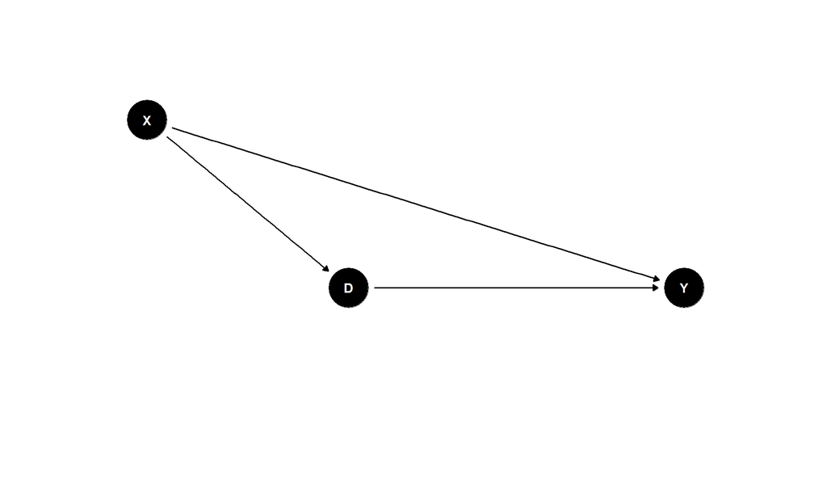

## Potential outcomes and estimands

**Potential outcomes model**

Causality is often formalized through the potential outcomes framework (Neyman (1923); Rubin (1974)).

- $Y_i$.
- $D_i \in \{0,1\}$.
- $\boldsymbol{X}_i$.
- $\mu (d, \boldsymbol{x}) := \mathbb{E} [ Y_i | D_i = d, \boldsymbol{X}_i = \boldsymbol{x}]$.
- $\pi (\boldsymbol{x}) := \mathbb{E} [ D_i = 1 | \boldsymbol{X}_i = \boldsymbol{x}]$.
- $Y_i(0), Y_i(1)$.
- $Y_i = D_i Y_i(1) + (1 - D_i) Y_i(0)$.

Under this model, the individual causal effect is $Y_i(1) - Y_i(0)$.

→ Never observable, as the counterfactual is missing.

Therefore, we focus on estimands that are identifiable under (somewhat) reasonable assumptions.

- $\text{ATE} → \tau := \mathbb{E}[Y_i(1) - Y_i(0)]$.
- $\text{GATE} → \tau_\color{#06b6d4}{g} := \mathbb{E}[Y_i(1) - Y_i(0) | \color{#06b6d4}{G_i = g}]$.
- $\text{CATE} → \tau(\color{#f59e0b}{\boldsymbol{x}}) := \mathbb{E}[Y_i(1) - Y_i(0) | \color{#f59e0b}{\boldsymbol{X}_i = \boldsymbol{x}}]$.

Two important special cases of $\tau_g$:

- $\text{ATT} := \mathbb{E}[Y_i(1) - Y_i(0) | \color{#c1121f}{D_i = 1}]$.
- $\text{ATNT} := \mathbb{E}[Y_i(1) - Y_i(0) | \color{#c1121f}{D_i = 0}]$.

## Mean difference decomposition

**Naive comparisons won’t cut it**

One might be tempted to simply compare mean outcomes for treated ($D_i = 1$) and control ($D_i = 0$) units. However,

$$\begin{aligned}
\mathbb{E} [ Y_i | D_i = 1] - \mathbb{E} [ Y_i | D_i = 0] & = \mathbb{E} [ Y_i(1) | D_i = 1] - \mathbb{E} [ Y_i(0) | D_i = 0] \\
&= \mathbb{E} [ Y_i(1) | D_i = 1] + \color{#06b6d4}{\mathbb{E} [Y_i (0) | D_i = 1]} - \color{#06b6d4}{\mathbb{E} [Y_i (0) | D_i = 1]} - \mathbb{E} [ Y_i(0) | D_i = 0] \\
&= \underbrace{\mathbb{E} [ Y_i(1) - Y_i (0)| D_i = 1]}_{\text{ATT}} + \underbrace{\mathbb{E} [Y_i (0) | D_i = 1] - \mathbb{E} [ Y_i(0) | D_i = 0]}_{\text{Selection bias}}.
\end{aligned}
\tag{1}$$

**Exercise$—$Randomization kills selection bias ($\approx 5$ minutes)**

Show that, if treatment is randomly assigned$—$that is, if

$$Y_i(1), Y_i(0) \perp D_i,$$
then $\mathbb{E} [ Y_i | D_i = 1] - \mathbb{E} [ Y_i | D_i = 0] = \text{ATT}$.

**Solution**. Under randomization, $\mathbb{E} [Y_i (d) | D_i = d] = \mathbb{E} [Y_i (d) | D_i = 1 - d] = \mathbb{E} [Y_i (d)]$ for $d = 0, 1$. Therefore, it’s simply a matter of “dropping the conditioning” from (1).

As a corollary, randomization ensures that $\text{ATT} = \text{ATNT} = \text{ATE}$.

## Selection-on-observables

**Observational data**

Randomization is ideal but often infeasible (costs, ethics, logistics) and may limit external validity. We can still identify causal effects using observational data with appropriate designs and assumptions.

**Selection-on-observables**

Selection-on-observables research designs are used when

- units are observed at a specific point in time,
- some receive treatment, and
- data on both pre-treatment characteristics and post-treatment outcomes are available.

This approach is based on the following assumptions (see, e.g., Imbens & Rubin (2015)):

**Assumption 1** **(Unconfoundedness).** $Y_i(1), Y_i(0) \perp D_i | \boldsymbol{X}_i$.

→ $\boldsymbol{X}_i$ fully accounts for selection into treatment$—$we observe all confounders.

**Assumption 2** **(Positivity).** $0 < \pi(\boldsymbol X_i) < 1$.

→ “Valid comparisons” exist.

Together, Assumptions 1$\text{-}$2 allow for the identification of $\tau$ and its conditional versions.

→ Meaningful comparisons between treated and control units with similar observed characteristics.

## Conditional mean difference decomposition

**Even naive conditional comparisons won’t cut it**

Without assuming that $\boldsymbol{X}_i$ fully accounts for selection into treatment, contrasts between treated and controls units with similar observed characteristics are off:

$$\begin{aligned}
\mu(1, \boldsymbol{x}) - \mu(0, \boldsymbol{x}) & = \mathbb{E} [ Y_i(1) | D_i = 1, \boldsymbol{X}_i = \boldsymbol{x}] - \mathbb{E} [ Y_i(0) | D_i = 0, \boldsymbol{X}_i = \boldsymbol{x}] \\
&= \mathbb{E} [ Y_i(1) | D_i = 1, \boldsymbol{X}_i = \boldsymbol{x}] - \mathbb{E} [ Y_i(0) | D_i = 0, \boldsymbol{X}_i = \boldsymbol{x}] \\
& + \color{#06b6d4}{\mathbb{E} [Y_i (0) | D_i = 1, \boldsymbol{X}_i = \boldsymbol{x}]} - \color{#06b6d4}{\mathbb{E} [Y_i (0) | D_i = 1, \boldsymbol{X}_i = \boldsymbol{x}]} \\
&= \underbrace{\mathbb{E} [ Y_i(1) - Y_i (0)| D_i = 1, \boldsymbol{X}_i = \boldsymbol{x}]}_{\text{CATT}(\boldsymbol{x})} + \underbrace{\mathbb{E} [Y_i (0) | D_i = 1, \boldsymbol{X}_i = \boldsymbol{x}] - \mathbb{E} [ Y_i(0) | D_i = 0, \boldsymbol{X}_i = \boldsymbol{x}]}_{\text{Selection bias}(\boldsymbol{x})}.
\end{aligned}
\tag{2}$$

**Exercise$—$Selection-on-observables kills conditional selection bias ($\approx 5$ minutes)**

Show that, under Assumptions 1$\text{-}$2,

$$\mu(1, \boldsymbol{X}_i) - \mu(0, \boldsymbol{X}_i) = \tau ( \boldsymbol{X}_i ).$$

**Solution**. Under Assumption 1,

$$\mathbb{E} [Y_i (d) | D_i = d, \boldsymbol{X}_i = \boldsymbol{x}] = \mathbb{E} [Y_i (d) | D_i = 1 - d, \boldsymbol{X}_i = \boldsymbol{x}] = \mathbb{E} [Y_i (d) | \boldsymbol{X}_i = \boldsymbol{x}], \quad \text{for } d = 0, 1.$$
Therefore, it’s simply a matter of “dropping the conditioning” from (2).

→ Assumption 2 is needed to ensure that all the conditional expectations are well-defined for all values within the support of $\boldsymbol{X}_i$.

As a corollary, Assumptions 1$\text{-}$2 ensure that $\text{CATT} = \text{CATNT} = \text{CATE}$.

## Exercise

**Exercise$—$Understanding DAGs ($\approx 5$ minutes)**

Discuss and answer the following questions.

- **Q1**. In each DAG, is the naive difference in means an unbiased ATE estimator?
- **Q2**. For each DAG, which variable(s) act as confounders?
- **Q3**. In the top DAG, do we need to control for $Z$?
- **Q3**. In the bottom DAG, should we control for $C$?

**Solution**.

- The difference in means is biased in both DAGs, as $X$ affects both $D$ and $Y$.
- $X$ is a confounder in both DAGs.
- No; $Z$ directly affects only $D$ and impacts $Y$ only through $D$, so it is not a confounder.

→ We call $Z$ an *instrument*.

- No; doing so “opens the path” and creates a spurious association between $D$ and $Y$.

→ We call $C$ a *collider*.

**Exercise$—$Selection-on-observables trade-offs ($\approx 5$ minutes)**

Can you think of any trade-off between Assumptions 1 and 2? Think about what happens if $\text{dim}(\boldsymbol{X}_i) \uparrow$.

**Solution.** As $\text{dim}(\boldsymbol{X}_i) \uparrow$, we (may) strengthen the credibility of unconfoundedness; however, we simultaneously make positivity less plausible.

→ Curse of dimensionality: the covariate space becomes sparse, and treated and control units may no longer overlap well.

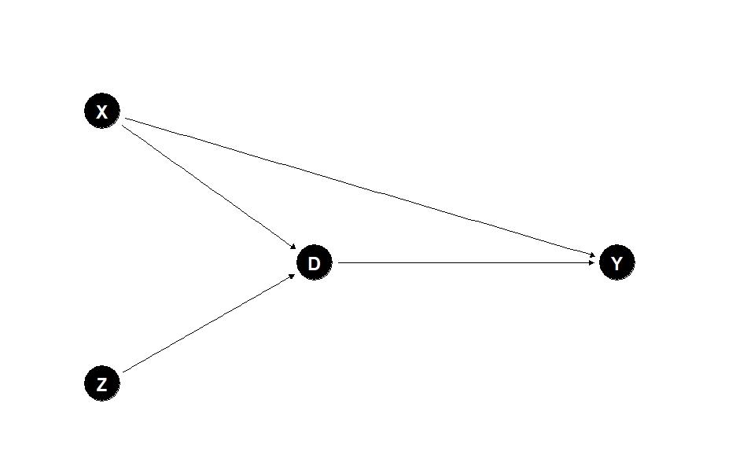

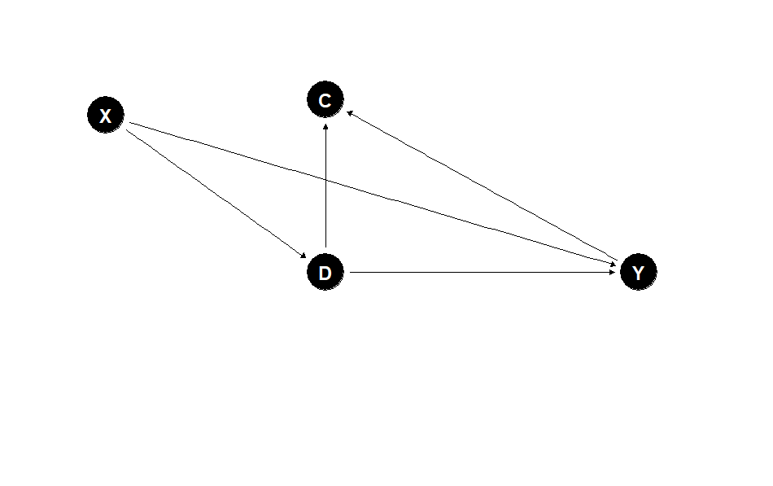

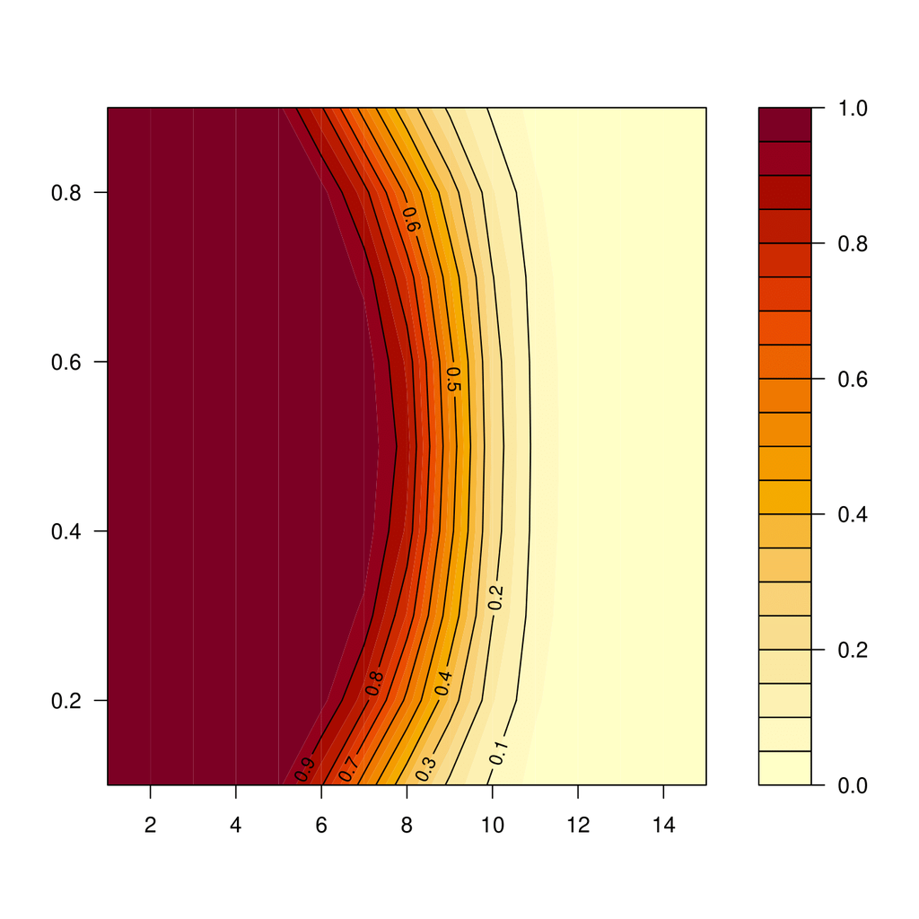

Countour plots of the probability of Assumption 2 holding true for different values of $\text{dim}(\boldsymbol{X}_i)$ ($x$-axis) and $\mathbb{E} [D_i]$ ($y$-axis). $n$ is fixed at $1000$.

## Building blocks for ATE estimation

**ATE identification under selection-on-observables**

Under Assumptions 1$\text{-}$2, the ATE can be written in three equivalent ways:

$$\tau = \mathbb{E}[\mu(1, \boldsymbol{X}_i) - \mu(0, \boldsymbol{X}_i)].$$
$$\tau = \mathbb{E} \left[\frac{D_i Y_i}{\pi ( \boldsymbol{X}_i)} - \frac{(1 - D_i) Y_i}{1 - \pi ( \boldsymbol{X}_i)} \right].$$
$$\tau = \mathbb{E} \left[\mu(1, \boldsymbol{X}_i) - \mu(0, \boldsymbol{X}_i) + \frac{D_i (Y_i - \mu(1, \boldsymbol{X}_i))}{\pi ( \boldsymbol{X}_i)} - \frac{(1 - D_i) (Y_i - \mu(0, \boldsymbol{X}_i))}{1 - \pi ( \boldsymbol{X}_i)} \right].$$

These equalities point to different estimation strategies, all relying on learning unknown nuisance functions.

→ We might need a high-dimensional $\boldsymbol{X}_i$ to satisfy Assumption 1. Machine learning is thus attractive.

**Cross-fitting**

Naive plug-in ML of nuisance functions can introduce overfitting bias.

- Split data into $I_1, \dots, I_K$ ($\approx$ equal size).
- Let $I_k^c = \{1, \dots, n\} \setminus I_k$ and $k(i)$ be $i$’s fold.
- For each $k$:
  1. Train $\hat\mu_{-k}, \hat\pi_{-k}$ on $I_k^c$;
  2. Predict on $I_k$ using $\hat\mu_{-k}, \hat\pi_{-k}$.
- Stack all out-of-fold scores; average for the final estimator.

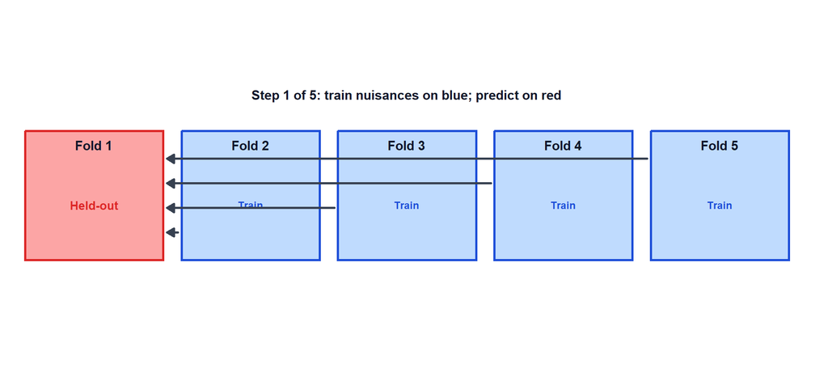

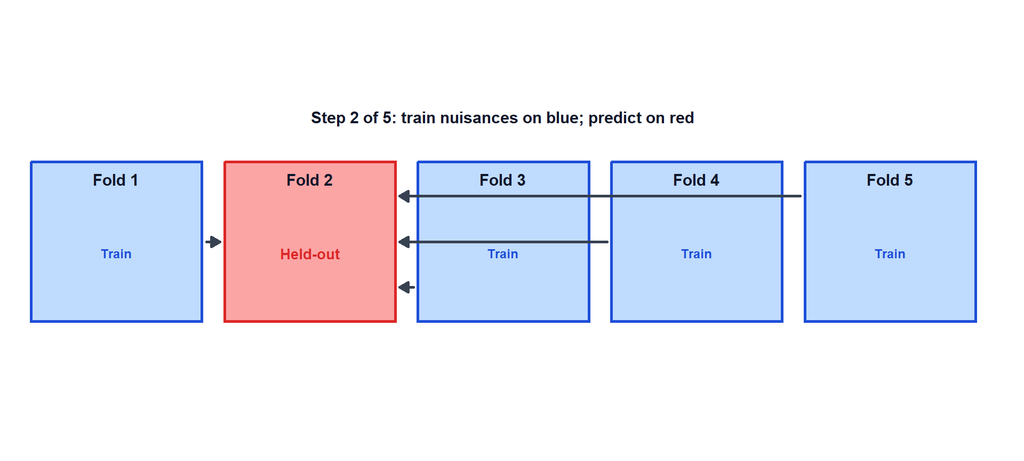

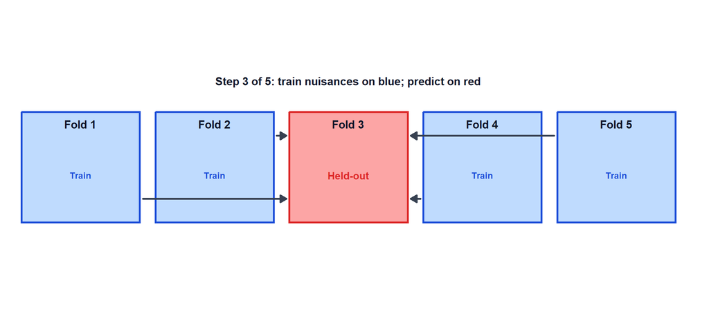

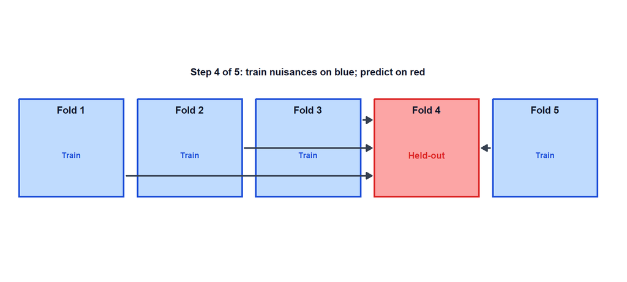

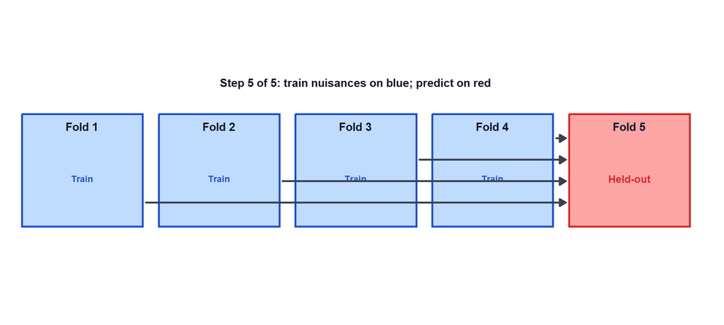

## Exercise

**Exercise$—$Suitable estimators ($\approx 3$ minutes)**

Discuss and list suitable estimators for $\mu(\cdot, \cdot)$ and $\pi(\cdot)$.

**Solution**. Notice that $\pi(\boldsymbol{X}_i) = \mathbb{P} (D_i = 1 | \boldsymbol{X}_i)$$—$the propensity score equals the “probability of success” of $D_i$.

→ We already learnt how LPM/Logit/Probit can help us here.

→ ML provides flexible alternatives (e.g., classification trees/forests/boosting, penalized regressions).

The estimation of $\mu(\cdot, \cdot)$ can be carried out differently according to the outcome’s nature.

→ (Penalized) linear models or regression trees/forests/boosting if $Y_i$ is continuous.

→ Classification algorithms if $Y_i$ is binary.

→ Ordered Logit/Probit or Ordered Correlation Forest (Di Francesco (2025)) if $Y_i$ is ordered.

**Exercise$—$Cross-fitting trade-offs ($\approx 3$ minutes)**

Discuss trade-offs when changing the number of folds $K$.

**Solution**. As $K$ increases, we expect more stable nuisance fits, as the training size increases. Carrying the argument to its extreme, one could implement a “leave-one-out” approach by setting $K = n$.

However, computational time increases in $K$, as nuisances must be fit $K$ times; this could lead to infeasibility if $n$ is large and we use “heavy” ML methodologies.

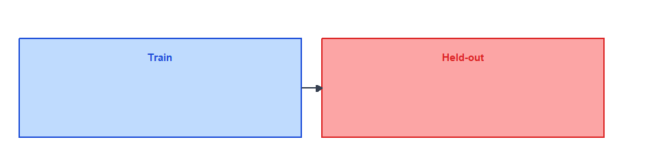

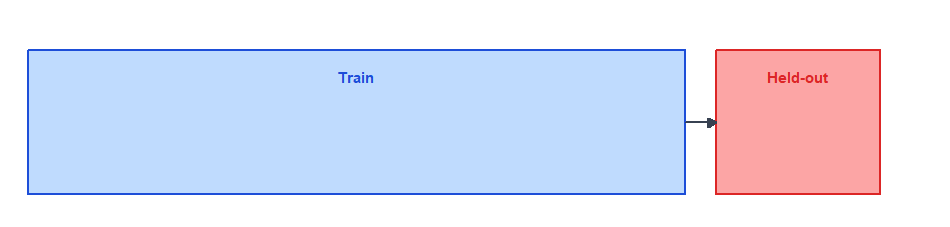

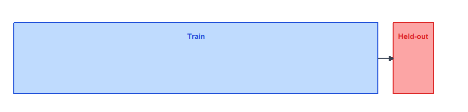

## Outcome regression

**Outcome regression identification of ATE**

Under selection-on-observables, we can write

$$\tau = \mathbb{E}[\mu(1, \boldsymbol{X}_i) - \mu(0, \boldsymbol{X}_i)].
\tag{3}$$

Equation (3) motivates the plug-in estimator

$$\hat{\tau}^{OR} = \frac{1}{n} \sum_{i = 1}^n \left[ \hat{\mu}_{-k(i)}(1, \boldsymbol{X}_i) - \hat{\mu}_{-k(i)}(0, \boldsymbol{X}_i) \right].
\tag{4}$$

**Asymptotic Normality of OR Estimator**

Suppose $\mathrm{RMSE}(\hat{\mu}_{-k}) = o_p(n^{-1/2})$ for $k = 1, \dots, K$. Then,
$$\sqrt{n} ( \hat{\tau}^{OR} - \tau) \xrightarrow{d} \mathcal{N}\left(0, \mathbb{V}\left(\mu(1, \boldsymbol{X}) - \mu(0, \boldsymbol{X}) \right) \right).$$
Furthermore,
$$\widehat{\mathbb{V}}_n^{OR} := \frac{1}{n} \sum_{i = 1}^n \left( \hat{\mu}_{-k(i)} (1, \boldsymbol{X}_i) - \hat{\mu}_{-k(i)} (0, \boldsymbol{X}_i) - \hat{\tau}^{OR} \right)^2
\xrightarrow{p} \mathbb{V}\left(\mu(1, \boldsymbol{X}) - \mu(0, \boldsymbol{X})\right).$$

## Inverse probability weighting

**IPW identification of ATE**

Under selection-on-observables, we can write

$$\tau = \mathbb{E} \left[ \frac{D_i Y_i}{\pi(\boldsymbol{X}_i)} - \frac{(1 - D_i) Y_i}{1 - \pi(\boldsymbol{X}_i)}\right].
\tag{5}$$

Equation (5) motivates the plug-in estimator

$$\hat{\tau}^{IPW} = \frac{1}{n}\sum_{i=1}^n \left[\frac{D_i Y_i}{\hat{\pi}_{-k(i)}(\boldsymbol{X}_i)} - \frac{(1 - D_i) Y_i}{1 - \hat{\pi}_{-k(i)}(\boldsymbol{X}_i)} \right].
\tag{6}$$

**Asymptotic Normality of IPW Estimator**

Suppose $0 < \hat\pi(\boldsymbol{X}_i) < 1$ and $\mathrm{RMSE} (\hat{\pi}_{-k}) = o_p(n^{-1/2})$ for $k = 1, \dots, K$. Then
$$\sqrt{n} (\hat{\tau}^{IPW}- \tau) \xrightarrow{d} \mathcal{N} \left(0, \mathbb{V} \left( \frac{D Y}{\pi(\boldsymbol{X})} - \frac{(1-D) Y}{1-\pi(\boldsymbol{X})}\right) \right).$$

Furthermore,
$$\widehat{\mathbb{V}}^{IPW}_n :=
\frac{1}{n}\sum_{i=1}^n
\left(
\frac{D_i Y_i}{\hat{\pi}_{-k(i)}(\boldsymbol{X}_i)}
- \frac{(1-D_i) Y_i}{1-\hat{\pi}_{-k(i)}(\boldsymbol{X}_i)}
- \hat{\tau}^{IPW}
\right)^2
\xrightarrow{p}
\mathbb{V}\left(
\frac{D Y}{\pi(\boldsymbol{X})} - \frac{(1-D) Y}{1-\pi(\boldsymbol{X})}
\right).$$

## Augmented inverse probability weighting

**AIPW identification of ATE**

Define
$$\psi \left( \boldsymbol{X}_i \right)
:= \underbrace{\mu(1, \boldsymbol{X}_i) - \mu(0, \boldsymbol{X}_i)}_{\text{OR}}
+ \underbrace{\frac{D_i \left( Y_i - \mu(1, \boldsymbol{X}_i) \right)}{\pi(\boldsymbol{X}_i)} - \frac{(1 - D_i) \left( Y_i - \mu(0, \boldsymbol{X}_i) \right)}{1 - \pi(\boldsymbol{X}_i)}}_{\text{IPW on residuals}}.
\tag{7}$$

Under selection-on-observables, we can write

$$\tau = \mathbb{E} \left[ \psi \left( \boldsymbol{X}_i \right) \right].
\tag{8}$$

Equation (8) motivates the plug-in estimator

$$\hat{\tau}^{AIPW} = \frac{1}{n}\sum_{i=1}^n \hat\psi_{-k(i)} (\boldsymbol{X}_i).
\tag{9}$$

**Asymptotic Normality of AIPW Estimator**

Suppose $0 < \hat\pi(\boldsymbol{X}_i) < 1$ and $\mathrm{RMSE}(\hat{\mu}_{-k}) \cdot \mathrm{RMSE}(\hat{\pi}_{-k}) = o_p(n^{-1/2})$ for $k = 1, \dots, K$. Then
$$\sqrt{n} \left( \hat{\tau}^{AIPW} - \tau \right)
\xrightarrow{d}
\mathcal{N} \left( 0, \mathbb{V} \left( \psi \left( \boldsymbol{X}_i \right) \right) \right),$$
$$\widehat{\mathbb{V}}^{AIPW}_n
:= \frac{1}{n} \sum_{i = 1}^n \left( \hat \psi \left( \boldsymbol{X}_i \right) - \hat \tau^{AIPW} \right)^2
\xrightarrow{p}
\mathbb{V} \left( \psi \left( \boldsymbol{X} \right) \right).$$

## Oracle + plug-in bias

**Decomposition of OR, IPW, and AIPW estimators**

Let $W_i := (Y_i, D_i, \boldsymbol{X}_i)$ and let $\eta := (\mu, \pi)$ collect the nuisance functions. The ATE estimators can be written as
$$\hat{\tau} = \frac{1}{n} \sum_{i = 1}^n m (W_i;\, \hat{\eta}_{-k(i)}),
\tag{10}$$

where $m(\cdot; \eta)$ is the estimator’s score.

Adding and subtracting the oracle score $m(W_i; \eta)$ and rearranging,
$$\hat{\tau} =
\underbrace{\frac{1}{n} \sum_{i = 1}^n m \left(W_i; \eta \right)}_{\text{oracle term}}
+
\underbrace{\frac{1}{n} \sum_{i = 1}^n \left[
m ( W_i; \hat{\eta}_{-k(i)}) - m \left(W_i; \eta\right)
\right]}_{\text{plug-in bias}}.
\tag{11}$$

**Comparing requirements on nuisance estimation**

To obtain asymptotically well-behaved estimates, OR, IPW, and AIPW need nuisances to be estimated accurately enough to control the plug-in bias.

- OR requires $\mathrm{RMSE}(\hat{\mu}_{-k}) = o_p(n^{-1/2})$.
- IPW requires $\mathrm{RMSE}(\hat{\pi}_{-k}) = o_p(n^{-1/2})$.
- AIPW requires $\mathrm{RMSE}(\hat{\mu}_{-k}) \cdot \mathrm{RMSE}(\hat{\pi}_{-k}) = o_p(n^{-1/2})$.

A sufficient condition for AIPW is $\mathrm{RMSE}(\hat{\mu}_{-k}) = o_p(n^{-1/4})$ and $\mathrm{RMSE}(\hat{\pi}_{-k}) = o_p(n^{-1/4})$

→ AIPW controls the plug-in bias under weaker requirements on nuisance estimation accuracy.

## Toy simulation

**Data-generating process**

We run a simple Monte Carlo to illustrate the benefits of cross-fitting for AIPW estimation of the ATE.

- Generate $p$ i.i.d. covariates $X_{ij} \sim \mathcal N(0,1)$.
- Propensity score defined as $\pi(\boldsymbol X_i) = \Lambda (0.6 X_{i1} + 0.8 \sin(X_{i3}))$.
- Treatment assignment follows a Bernoulli process $D_i \sim \mathrm{Bernoulli}(\pi(\boldsymbol{X}_i))$.
- Control regression function is $\mu(0, \boldsymbol{X}_i) = 2\sin(X_{i1}) + 0.5 X_{i2}^2$.
- CATE function specified as $\tau(\boldsymbol{X}_i) = 1 + 0.5 \cdot \mathbf{1} \{X_{i1} > 0\}$.
- Generate observed outcomes as $Y_i = \mu(0, \boldsymbol{X}_i) + D_i \tau(\boldsymbol{X}_i) + \mathcal N(0,1)$.

We construct $\hat\tau^{AIPW}$ using regression/classification trees for nuisance estimation.

**Exercise$—$Understanding the DPG ($\approx$ 5 minutes)**

Discuss and answer the following questions.

- **Q1**. Is this DGP confounded?
- **Q2**. Which variable(s) are confounders?
- **Q3**. Is there treatment-effect heterogeneity?
- **Q4**. What’s the model of $\mu(1, \boldsymbol{X}_i)$?

**Solution**.

- Yes.

→ $X_{i1}$ enters the models of both $Y_i$ and $D_i$.

- $X_{i1}$ is the only confounder.

→ Controlling for $X_{i1}$ is enough for identification.

- Yes.

→ Effects are larger when $X_{i1} > 0$.

- Notice that $\mu(1, \boldsymbol{X}_i) = \tau(\boldsymbol{X}_i) + \mu(0, \boldsymbol{X}_i)$.

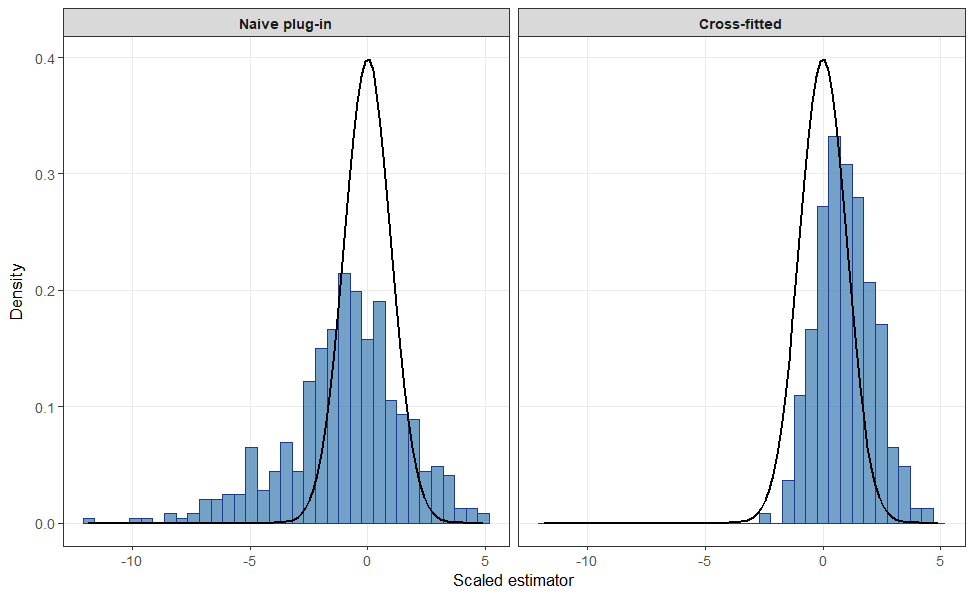

Results for $p = 15$, $n = 500$, and $K = 2$, with $500$ replications ($\approx$ 1 minute on my laptop).

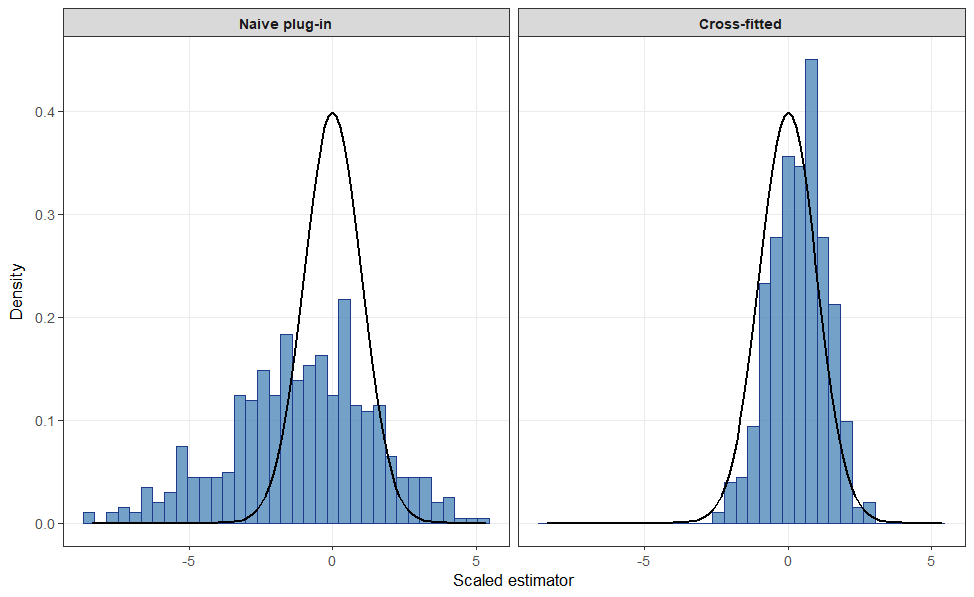

Results for $p = 15$, $n = 500$, and $\color{#c1121f}{K = 5}$, with $500$ replications ($\approx$ 2:30 minutes on my laptop).

## ATE vs. GATEs vs. CATEs

**Effect heterogeneity matters**

The ATE quantifies the average impact of the policy on the reference population.

→ Straightforward to interpret and communicate.

However, the ATE lacks information regarding effect heterogeneity.

→ Who benefits most/least? Any harmed groups? Are effects monotone?

To study heterogeneity, we can target

- GATEs (group ATEs), or
- CATEs (conditional ATEs).

**Exercise$—$How to tackle effect heterogeneity ($\approx$ 3 minutes)**

Discuss and answer the following questions.

- **Q1**. Can you think of some “natural” grouping rules?
- **Q2**. What are the trade-offs when changing the number of groups?
- **Q3**. What are the trade-offs between targeting GATEs vs CATEs?

**Solution**.

- Standard examples are age bands or gender/ethnicity strata.
- More groups → finer detail but smaller cells (noisy/fragile) and harder interpretation; fewer groups → stable but coarse.
- GATEs are simple to interpret, but need group choice and can miss within-group patterns. CATEs are more flexible, but harder to communicate and estimate.

## GATEs overview

**GATE analysis**

A common approach to tackle effect heterogeneity is to report the ATEs across different subgroups defined by observable covariates:

$$\tau_g := \mathbb{E} [Y_i(1) - Y_i(0) | G_i = g],$$
with $G_i = 1, \dots, G$ a discrete “group” indicator built from $\boldsymbol{X}_i$.

→ GATEs with continuous $G_i$ are more challenging to handle (Zimmert & Lechner (2019); Fan et al. (2022)).

If groups are “exogenous”$—$i.e., pre-specified$—$GATEs can be estimated by applying ATE estimators separately for each group:

$$\hat{\tau}_{\color{#c1121f}{g}} = \frac{1}{n_{\color{#c1121f}{g}}} \sum_{i = 1}^n \color{#c1121f}{\mathbf{1} \{G_i = g\}} \, m (W_i;\, \hat{\eta}_{-k(i)}), \quad g = 1, \dots, G.$$

This approach is simple to implement, but can be inefficient with many small groups.

A more efficient alternative is to project the CATEs on “group dummies.”

→ $\tau_g = \mathbb{E} [\tau(\boldsymbol{X}_i) | G_i = g]$ motivates modelling the *best linear predictor* of $\tau(\cdot)$ given $G_i$.

However, $\tau(\cdot)$ is unobserved. Fortunately, we can proxy it with $\psi(\cdot)$ (Semenova & Chernozhukov (2021)).

→ $\mathbb{E} [ \psi(\boldsymbol{X}_i) | \boldsymbol{X}_i] = \tau(\boldsymbol{X}_i)$.

$$\hat\psi_{-k(i)}(\boldsymbol{X}_i) = \sum_{g = 1}^G \mathbf{1} \{G_i = g\} \beta_g + \epsilon_i.
\tag{12}$$

Under selection-on-observables, $\beta_g = \tau_g$. With cross-fitting, Semenova & Chernozhukov ((2021)) show that the OLS estimator $\hat\beta_g$ is root-$n$ consistent and asymptotically normal, provided $\mathrm{RMSE}(\hat{\mu}_{-k}) \cdot \mathrm{RMSE}(\hat{\pi}_{-k}) = o_p(n^{-1/2})$.

## How to form groups

**Data-driven groups**

So far, we assumed groups were pre-specified. Pre-specifying groups is simple but risks missing unexpected heterogeneity.

Researchers often want to “let the data speak” and discover data-driven heterogeneous subgroups.

→ Tree-based approaches are popular because of their piece-wise constant structure.

However, data-driven groups are *endogenous*, and naive reuse of the same sample for grouping and estimation biases results.

A remedy is to combine tree-based approaches with honesty (Athey & Imbens (2016)).

1. Split the data into *training* and *honest* subsamples.
2. Construct a tree using training data.
3. Estimate leaf-ATEs using honest data.

**Causal trees** (Athey & Imbens (2016))

Grow tree by adapting splitting criterion to target effect heterogeneity, and estimate GATEs by

$$Y_i = \sum_{l = 1}^L L_{il} \gamma_l + \sum_{l = 1}^L L_{il} D_i \beta_l + \epsilon_i.$$

**Aggregation trees** (Di Francesco (2024))

Grow tree by applying standard CART to estimated CATEs, and estimate GATEs by
$$\hat\psi_{-k(i)}(\boldsymbol{X}_i) = \sum_{l = 1}^L L_{il} \beta_l + \epsilon_i.$$

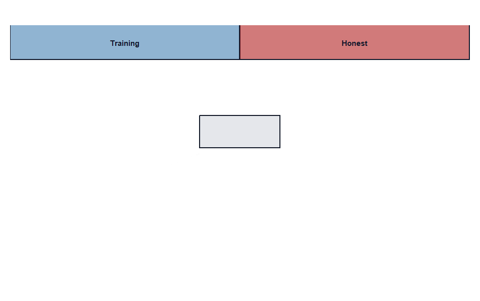

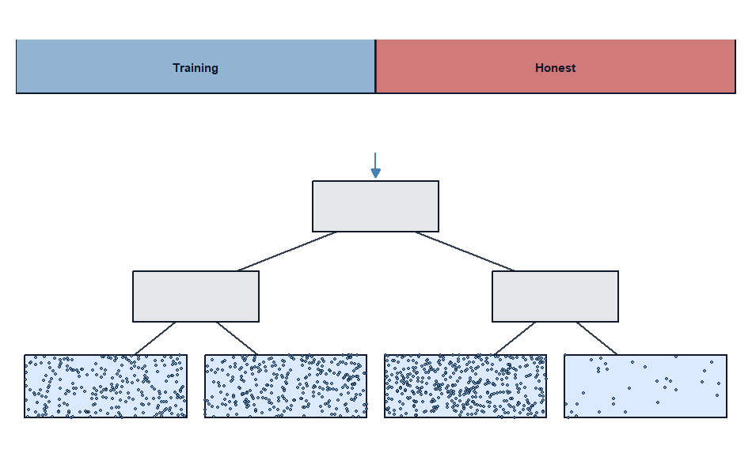

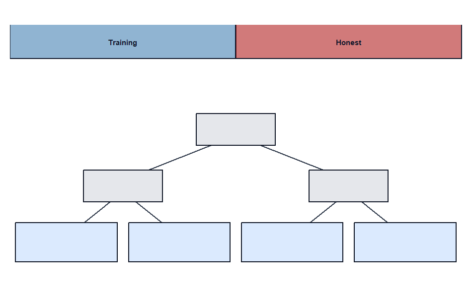

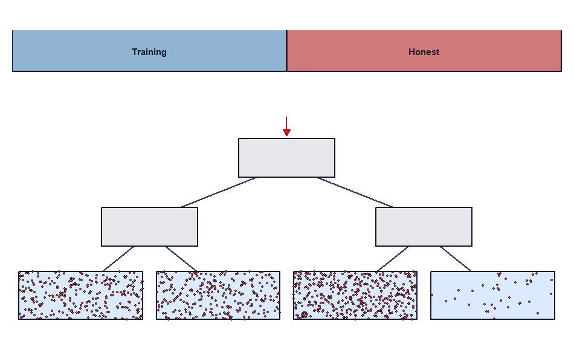

## Exercise

**Exercise$—$Honesty trade-offs ($\approx 3$ minutes)**

Discuss and answer the following questions.

- **Q1.** Does honesty come at a price?
- **Q2.** What are the trade-offs when varying the fraction of the sample allocated to the training vs. honest subsamples?

**Solution.**

- **Q1.** Yes. Sample splitting uses fewer observations for each task (splitting vs. effect estimation), which increases variance and typically reduces predictive accuracy in finite samples.
- **Q2.**
  - More data to training ⇒ better splits, but fewer observations in the honest sample ⇒ noisier effect estimates within each leaf.
  - More data to honesty ⇒ more precise effect estimates within leaves, but splits are learned from less data ⇒ coarser / less stable partitions
  - We balance these two sources of error: too little training data leads to bad trees; too little honest data leads to unreliable GATE estimates.

## CATE overview

**CATE estimation**

To “fully” tackle effect heterogeneity, we can focus on the CATEs
$$\tau (\boldsymbol{X}_i) := \mathbb{E} [ Y_i(1) - Y_i(0) | \boldsymbol{X}_i].$$
CATEs provide information at the finest level of granularity achievable with the covariates we observe.

→ They let us relate effect heterogeneity directly to observable covariates.

Moving from ATE/GATEs to CATEs means moving from the estimation of a low-dimensional parameter to the estimation of a high-dimensional function.

→ This is essentially a prediction problem, but the algorithm must output causal effects rather than outcome predictions.

Two broad strategies:

- Recast the CATE problem as a sequence of standard prediction tasks, or
- Modify ML algorithms so that they directly target causal quantities.

## CATE metalearners

**Decomposing the CATE problem**

Meta-learners (Künzel et al. (2019)) exploit the fact that the CATE problem can be recast as a sequence of standard prediction tasks, which can then be solved using any supervised learning algorithm.

**S-learner**

1. Train a single model $\hat\mu(d, \boldsymbol{x})$ by regressing $Y_i$ on $(D_i, \boldsymbol{X}_i)$ using all units.
2. For any $\boldsymbol{x}$, construct $\hat\tau^{S}(\boldsymbol{x}) = \hat\mu(1, \boldsymbol{x}) - \hat\mu(0, \boldsymbol{x})$.

**T-learner**

1. Train two models $\hat\mu(1, \cdot)$ and $\hat\mu(0, \boldsymbol{x})$ by regressing $Y_i$ on $\boldsymbol{X}_i$ separately in the treated and control samples.
2. For any $\boldsymbol{x}$, construct $\hat\tau^{T}(\boldsymbol{x}) = \hat\mu_1(\boldsymbol{x}) - \hat\mu_0(\boldsymbol{x})$.

**X-learner**

1. Train $\hat\mu(1, \cdot)$ and $\hat\mu(0, \cdot)$ as in the T-learner.
2. Impute treatment effects $\tilde\tau_{1,i} = Y_i - \hat\mu(0, \boldsymbol{X}_i)$ and $\tilde\tau_{0,i} = \hat\mu(1, \boldsymbol{X}_i) - Y_i$.
3. Fit two CATE models $\hat\tau_1(\boldsymbol{x})$ and $\hat\tau_0(\boldsymbol{x})$ by regressing $\tilde\tau_{d,i}$ on $\boldsymbol{X}_i$ in the corresponding subsamples.
4. Construct $\hat\tau^{X}(\boldsymbol{x}) = g(\boldsymbol{x}) \hat\tau_0(\boldsymbol{x}) + (1 - g(\boldsymbol{x})) \hat\tau_1(\boldsymbol{x})$ using any weight function $g(\boldsymbol{x}) \in [0, 1]$.

→ A common choice is $g(\boldsymbol{x}) = \hat\pi(\boldsymbol{x})$.

## Exercise

**Exercise$—$Meta-learners trade-offs ($\approx$ 5 minutes)**

Discuss the pros and cons of the S-, T-, and X-learner.

**Solution**.

- **S-learner**
  - ✅ Trains a single model on the full sample.
  - ✅ Very simple to implement: just treat $D_i$ as another covariate.
  - ❌ The learner may heavily regularize the contribution of $D_i$, effectively shrinking treatment effects toward zero.
  - ❌ Can perform poorly when treatment assignment is highly imbalanced.
- **T-learner**
  - ✅ Fits separate models for treated and control units, allowing very flexible and potentially very different response surfaces.
  - ✅ Avoids directly regularizing $D_i$ inside a single model.
  - ❌ Each model uses only one arm, so the effective sample size per model is smaller ⇒ higher variance, especially if one arm is small.
  - ❌ With poor overlap, one of the two models must extrapolate heavily.
- **X-learner**
  - ✅ Can explicitly exploit imbalance/overlap by letting each arm contribute more where it is better informed about local effects.
  - ✅ Often performs well when treatment is strongly imbalanced and base learners are flexible.
  - ❌ More complex: requires two outcome models, two “effect” models, and a weighting scheme $g(\boldsymbol{x})$.
  - ❌ Sensitive to first-stage quality: poor outcome models propagate bias into the imputed treatment effects.

## Toy simulation

**Data-generating process**

We run a simple Monte Carlo to compare S-, T-, and X-learners.

- Generate $p$ i.i.d. covariates $X_{ij} \sim \mathcal N(0,1)$.
- Propensity score defined as $e(\boldsymbol X_i) = \Lambda(-1.5 + 1.5 X_{i1})$.
- Treatment assignment follows a Bernoulli process $D_i \sim \mathrm{Bernoulli}(e(\boldsymbol{X}_i))$.
- Baseline regression function is $\mu(0, \boldsymbol{X}_i) = 2\sin(\pi X_{i1} X_{i2}) + 0.5 X_{i3}^2 + X_{i4}$.
- Generate observed outcomes as $Y_i = \mu(\boldsymbol{X}_i) + D_i \tau(\boldsymbol{X}_i) + \mathcal N(0,1)$.

We use regression forests as base learners, setting $p = 5$ and $n = 800$.

**Exercise$—$Reading the meta-learner simulation ($\approx$ 5 minutes)**

Discuss and answer the following questions.

- **Q1**. Which learner would you expect to have the lowest RMSE for $\tau(\boldsymbol X_i) = 0$?
- **Q2**. Why might the T-learner perform relatively poorly?

**Solution**.

- S-learner.

→ S-learner artificially shrinks effects towards zero$—$it’s “lucky” when treatment has no effect.

- T-learner suffers from high variance because treatment is imbalanced ($\mathbb{E} [D_i] \approx 0.25$).

→ Each model uses only one arm; in regions where one arm is rare, it must extrapolate heavily, leading to noisy and unstable predictions.

## Toy simulation$—$Results

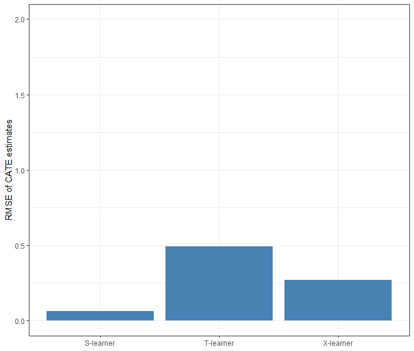

Results for $\tau(\boldsymbol{X_i}) = 0$, with $100$ replications ($\approx$ 15 seconds on my laptop).

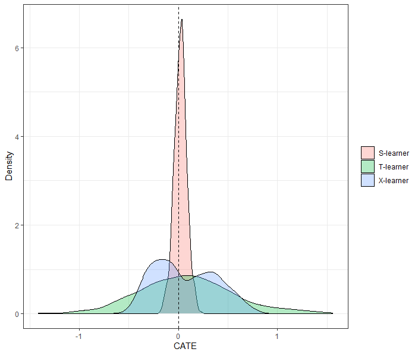

Results for $\tau(\boldsymbol{X_i}) = 0$, with $100$ replications ($\approx$ 15 seconds on my laptop).

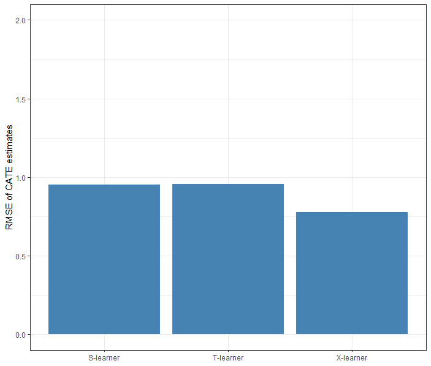

Results for $\tau(\boldsymbol{X_i}) = X_{i1}$, with $100$ replications ($\approx$ 15 seconds on my laptop).

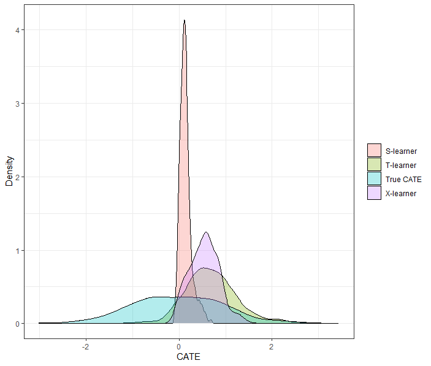

Results for $\tau(\boldsymbol{X_i}) = X_{i1}$, with $100$ replications ($\approx$ 15 seconds on my laptop).

## CATE validation

**High variance of CATE estimates $\neq$ heterogeneity**

Looking at the distribution of the estimated CATEs is not an effective strategy for assessing effect heterogeneity.

→ High variation in predictions due to estimation noise does not necessarily imply heterogeneous effects.

**Emerging literature on CATE validation**

There is an emerging literature on *CATE validation* that introduces methodologies to quantify how much signal a given CATE estimator is actually capturing.

- BLP, GATES, and CLAN analyses based on repeated sample splitting (Chernozhukov et al. (2017)).
- GATES analysis under Neyman’s repeated-sampling framework (Imai & Li (2025)).
- RATEs (Yadlowsky et al. (2025)).

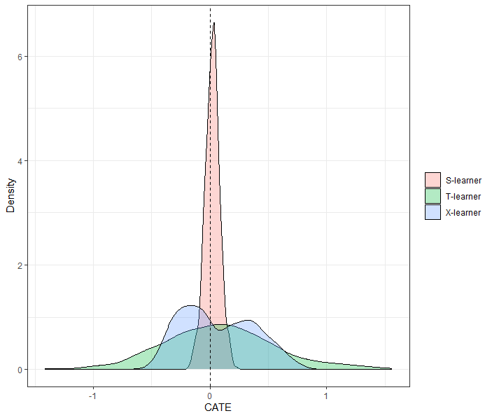

Results for $\tau(\boldsymbol{X_i}) = 0$, with $100$ replications ($\approx$ 15 seconds on my laptop).

## References

Athey, S., and G. W. Imbens. (2016): “Recursive partitioning for heterogeneous causal effects,” *Proceedings of the National Academy of Sciences*, 113, 7353–60.

Chernozhukov, V., M. Demirer, E. Duflo, and I. Fernández-Val. (2017): “Generic machine learning inference on heterogenous treatment effects in randomized experiments,” *arXiv preprint arXiv:1712.04802*,.

Di Francesco, R. (2024): “Aggregation trees,” *arXiv preprint arXiv:2410.11408*,.

---. (2025): “Ordered correlation forest,” *Econometric Reviews*, 44, 416–32.

Fan, Q., Y.-C. Hsu, R. P. Lieli, and Y. Zhang. (2022): “Estimation of conditional average treatment effects with high-dimensional data,” *Journal of Business & Economic Statistics*, 40, 313–27.

Imai, K., and M. L. Li. (2025): “Statistical inference for heterogeneous treatment effects discovered by generic machine learning in randomized experiments,” *Journal of Business & Economic Statistics*, 43, 256–68.

Imbens, G. W., and D. B. Rubin. (2015): *Causal Inference for Statistics, Social, and Biomedical Sciences: An Introduction*, Cambridge University Press.

Künzel, S. R., J. S. Sekhon, P. J. Bickel, and B. Yu. (2019): “Metalearners for estimating heterogeneous treatment effects using machine learning,” *Proceedings of the National Academy of Sciences*, 116, 4156–65.

Neyman, J. (1923): “Sur les applications de la théorie des probabilités aux experiences agricoles: Essai des principes,” *Roczniki Nauk Rolniczyc*, 10, 1–51.

Rubin, D. B. (1974): “Estimating causal effects of treatments in randomized and nonrandomized studies,” *Journal of Educational Psychology*, 66, 688--701.

Semenova, V., and V. Chernozhukov. (2021): “Debiased machine learning of conditional average treatment effects and other causal functions,” *The Econometrics Journal*, 24, 264–89.

Yadlowsky, S., S. Fleming, N. Shah, E. Brunskill, and S. Wager. (2025): “Evaluating treatment prioritization rules via rank-weighted average treatment effects,” *Journal of the American Statistical Association*, 120, 38–51.

Zimmert, M., and M. Lechner. (2019): “Nonparametric estimation of causal heterogeneity under high-dimensional confounding,” *arXiv preprint arXiv:1908.08779*,.